# Paired RNA-seq analysis

Yang

01/08/2019

### Setup

```r
library(limma)
library(edgeR)
library(AnnotationHub)
library(tidyverse)
library(magrittr)
library(pander)
library(RColorBrewer)
library(ggrepel)
library(swfdr)
library(qvalue)
library(scales)
library(here)
library(variancePartition)
library(org.Hs.eg.db)
library(plyr)
library(ggraph)
library(tidygraph)
library(fgsea)
library(pheatmap)
theme_set(theme_bw())
panderOptions("big.mark", ",")
panderOptions("table.split.table", Inf)
panderOptions("table.style", "rmarkdown")
if (interactive()) setwd(here::here("R"))
```

Annotation was set up as a EnsDb object based on Ensembl Release 96

```r
ah <- AnnotationHub() %>%
  subset(species == "Danio rerio") %>%
  subset(dataprovider == "Ensembl") %>%
  subset(rdataclass == "EnsDb")
ensDb <- ah[["AH69169"]]
genes <- genes(ensDb)
```

Prior to count-level analysis, the initial dataset was pre-processed using the following steps:

- Adapters were removed from any reads
- Bases were removed from the end of reads when the quality score dipped below 30
- Reads < 35bp after trimming were discarded

After trimming alignment was performed using STAR v2.5.3a to the *Danio rerio* genome included in Ensembl Release 96 (GRCz11). Aligned reads were counted for each gene if the following criteria were satisfied:

- Alignments were unique
- Alignments strictly overlapped exonic regions

```r
minSamples <- 6
minCpm <- 2
```

```r
counts <- file.path("../2_alignedData/featureCounts/genes.out") %>%
    read_tsv() %>%
    set_colnames(basename(colnames(.))) %>%
    set_colnames(str_remove(colnames(.), "Aligned.+")) %>%
  gather(key = "Library", value = "Counts", -Geneid) %>%
  dplyr::mutate(Sample = str_remove_all(Library, "_2")) %>%
  group_by(Geneid, Sample) %>%
  dplyr::summarise(Counts = sum(Counts)) %>%
  tidyr::spread(key = "Sample", value = "Counts") %>%
  as.data.frame() %>%
  column_to_rownames("Geneid")
genes2keep <- cpm(counts) %>%
  is_greater_than(minCpm) %>%
  rowSums() %>%
  is_weakly_greater_than(minSamples)
```

Counts were then loaded and summed across replicate sequencing runs. Genes were only retained if receiving more than 2 cpm in at least 6 samples. This filtering step discarded 14,446 genes as undetectable and retained 17,611 genes for further analysis.

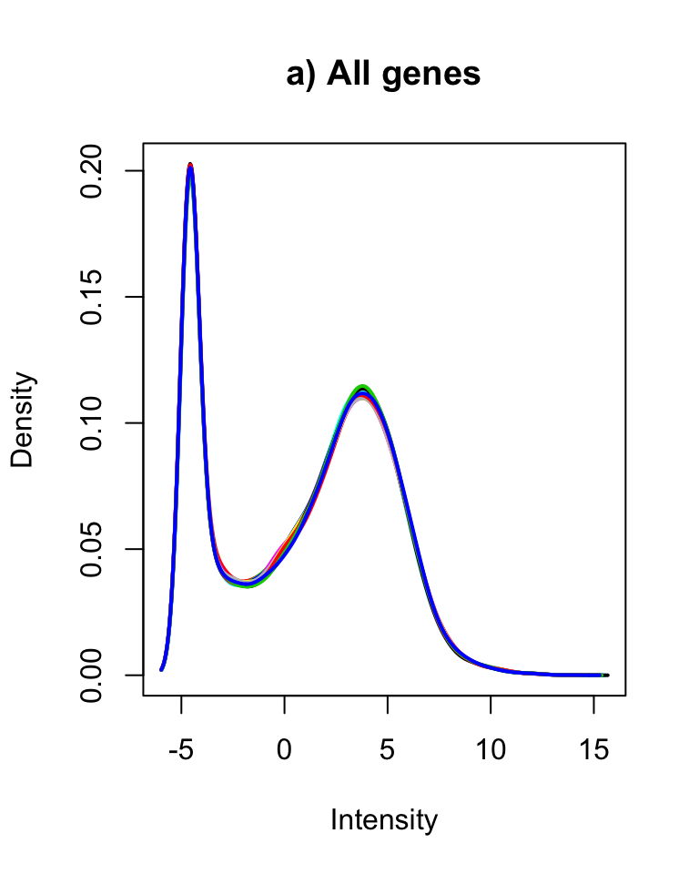

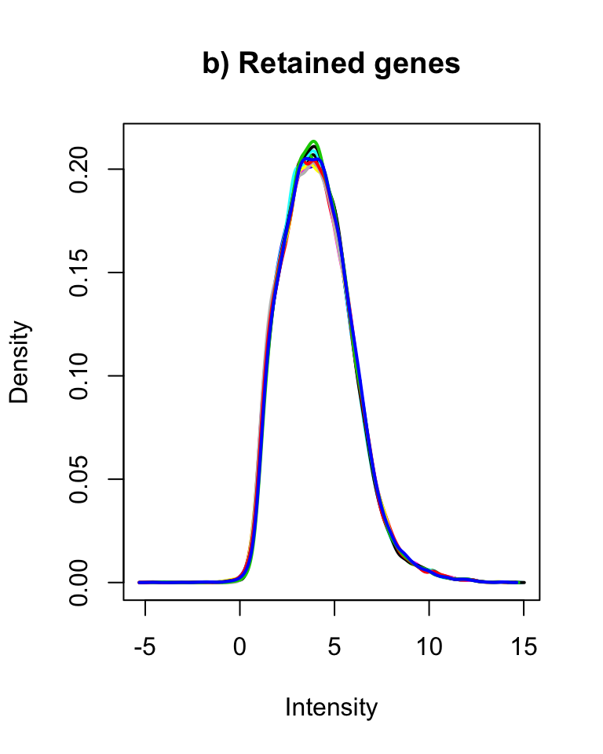

Distribution of logCPM values for a) all and b) retained genes

```r
plotDensities(cpm(counts, log = TRUE), legend = FALSE, main = "a) All genes")
plotDensities(cpm(counts[genes2keep,], log = TRUE), legend = FALSE, main = "b) Retained genes")
```

```r
dgeList <- counts %>%
  .[genes2keep,] %>%
  DGEList(
    samples = tibble(
      sample = colnames(.),
      group = str_replace_all(sample, "[0-9]*[A-Z]([12])Lardelli", "\\1"),
      pair = str_replace_all(sample, "[0-9]*([A-Z])[0-9].+", "\\1")
    ) %>%
      as.data.frame(),
        genes = genes[rownames(.)] %>%
            as.data.frame() %>%
            dplyr::select(
                ensembl_gene_id = gene_id,
                chromosome_name = seqnames,
                description,
                external_gene_name = gene_name
            )
    ) %>%
    calcNormFactors(method = "TMM") %>%
    estimateDisp()
```

```
## Design matrix not provided. Switch to the classic mode.
```

```r
dgeList$samples$Genotype <- c("Q96K97del/+", "WT")[dgeList$samples$group] %>%
  factor(levels = c("WT", "Q96K97del/+"))
```

Counts were then formed into a DGEList object. Library sizes after alignment, counting and gene filtering ranged between *44,383,915* and *52,639,358* reads.

### Data Inspection

```r
v <- dgeList %>%
    voomWithQualityWeights(design = matrix(1, nrow = ncol(.)))
```

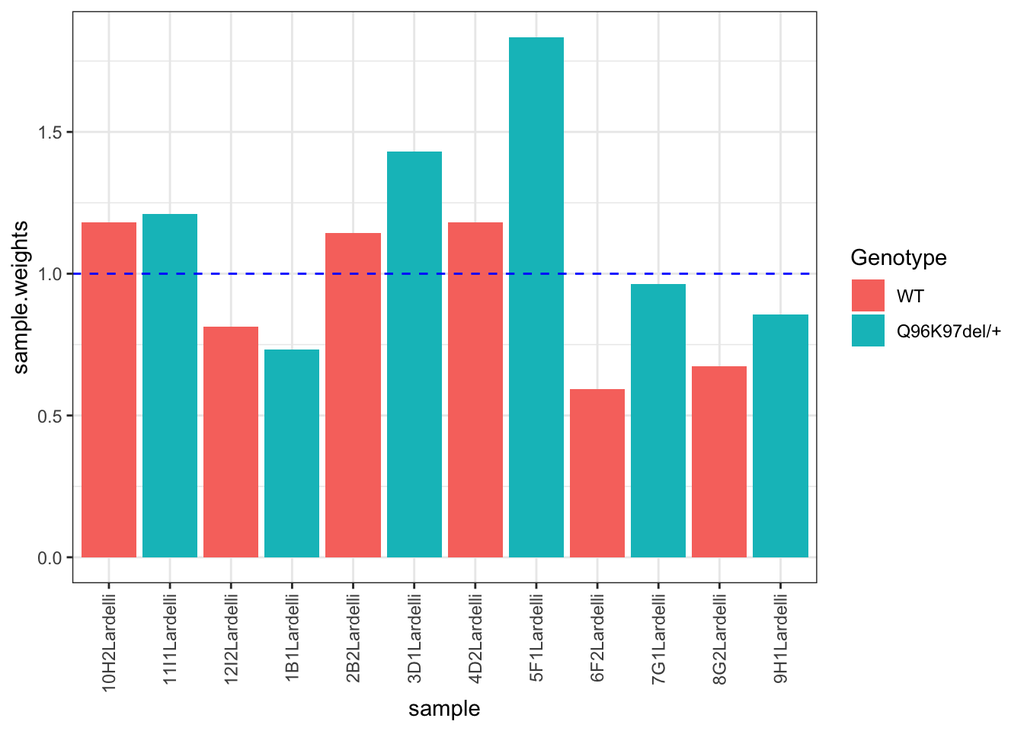

Sample weights with the ideal equal weight of 1 shown as a horizontal line.

```r
pca <- v$E %>%
    t() %>%
    prcomp()
summary(pca)$importance %>% pander(split.tables = Inf)
```

|  | PC1 | PC2 | PC3 | PC4 | PC5 | PC6 | PC7 | PC8 | PC9 | PC10 | PC11 | PC12 |
| --- | --- | --- | --- | --- | --- | --- | --- | --- | --- | --- | --- | --- |
| **Standard deviation** | 20.01 | 16.22 | 11.78 | 10.96 | 9.725 | 9.39 | 8.922 | 8.462 | 8.132 | 6.586 | 6.127 | 4.294e-14 |
| **Proportion of Variance** | 0.2854 | 0.1875 | 0.09885 | 0.08552 | 0.06738 | 0.06282 | 0.05671 | 0.05102 | 0.04712 | 0.0309 | 0.02674 | 0 |
| **Cumulative Proportion** | 0.2854 | 0.4729 | 0.5718 | 0.6573 | 0.7247 | 0.7875 | 0.8442 | 0.8952 | 0.9424 | 0.9733 | 1 | 1 |

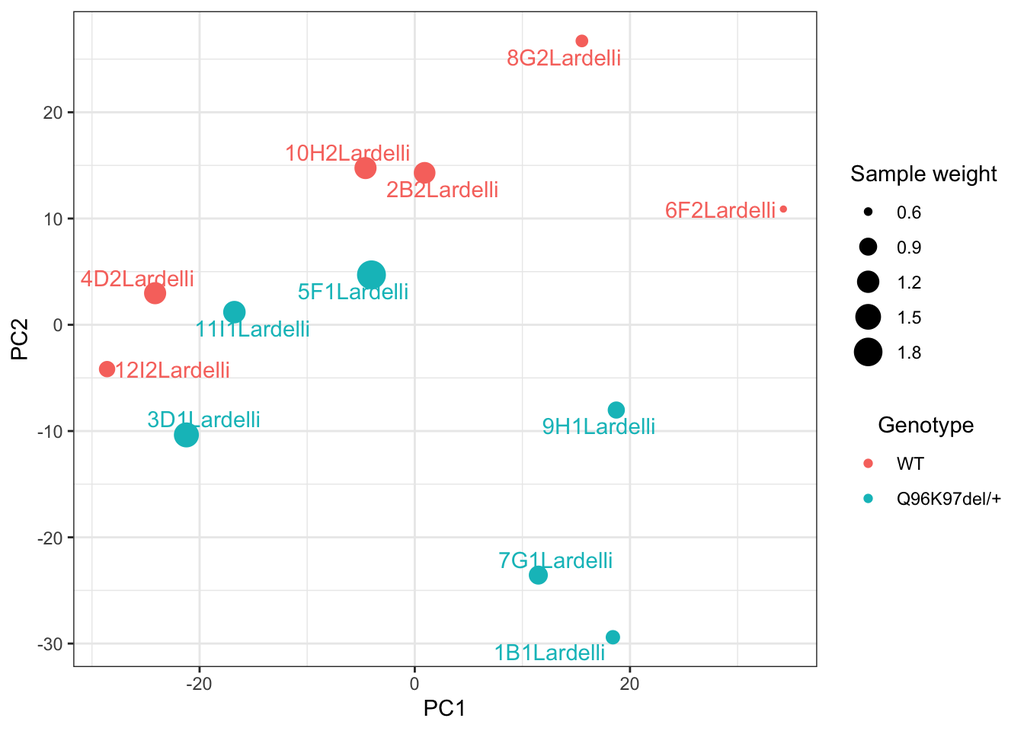

psen1 expression checking

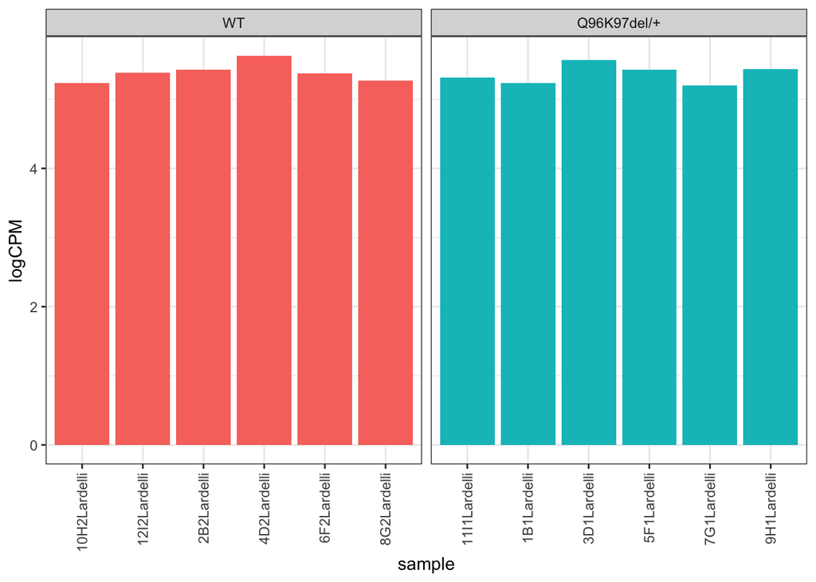

Expression of *psen1* across all samples.

rpl13 expression checking (house-keeping gene)

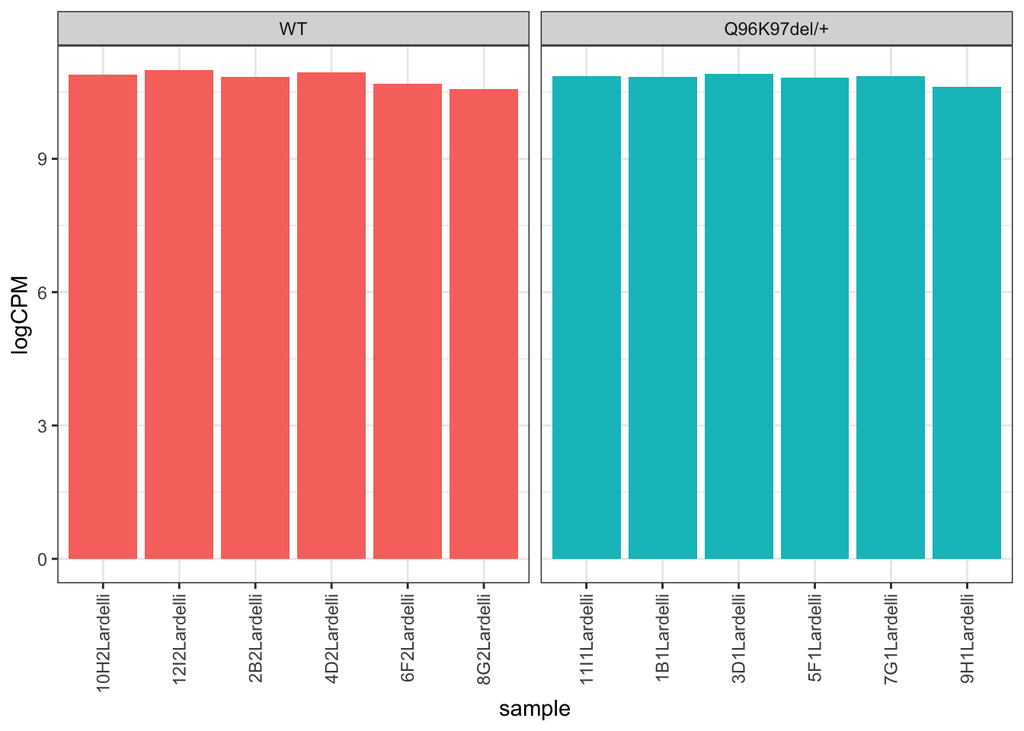

Expression of *rpl13* across all samples.

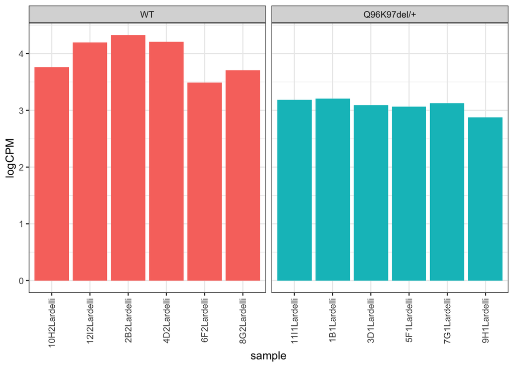

Expression of *si:ch211-11p18.6* across all samples.

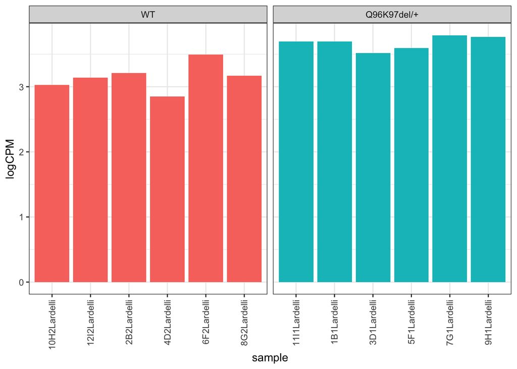

Expression of *bmp4* across all samples.

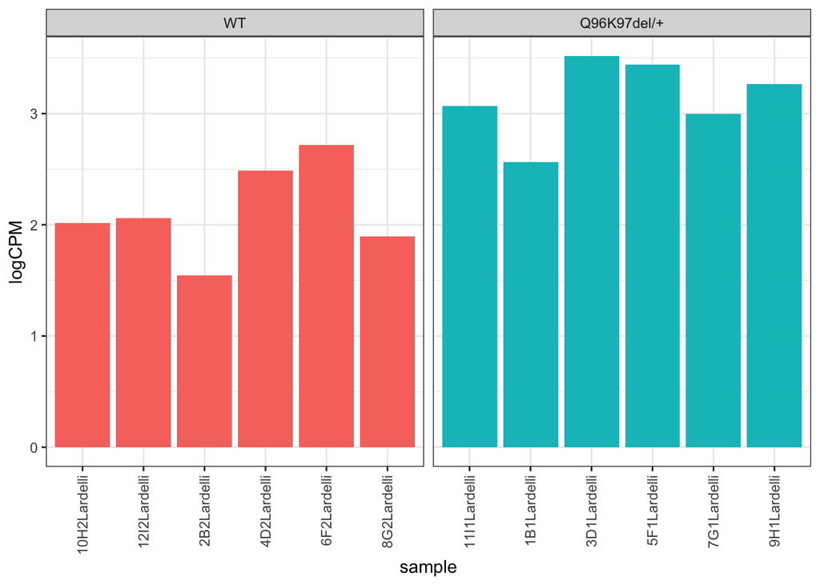

Expression of *si_ch211-213a13.2* across all samples.

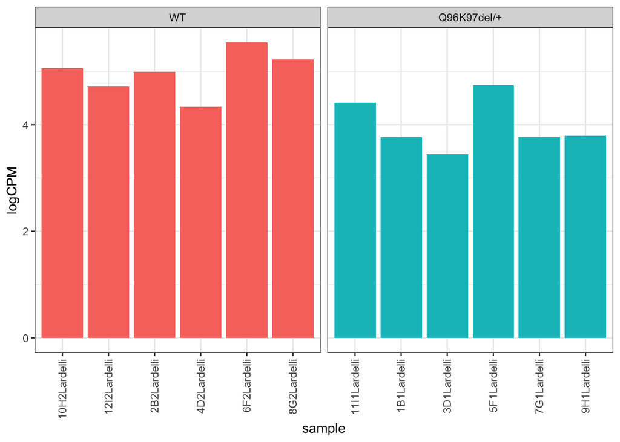

Expression of *mdh1ab* across all samples.

###DGE Analysis

To run a mixed-effects (nested) analysis we must use a voom object. Here we are looking at the change due to genotype within each pair. We then look at the mean of the differences, instead of the difference in means.

```r
voomData <- voom(dgeList, plot = FALSE)
```

```r
fm <- ~ Genotype + (1|pair)
contrMat <- getContrast(voomData, fm, voomData$targets, "GenotypeQ96K97del/+")
```

```r
library(doParallel)
cl <- makeCluster(7)
registerDoParallel(cl)
fit <- dream(voomData, fm, voomData$targets, contrMat) %>% eBayes()
```

```
## Projected memory usage: > 506.5 Mb
##
## Finished...
## Total: 290 s
```

```r
# stop cluster
stopCluster(cl)
```

```r
deGenes <- topTable(fit, n = Inf) %>%
  as_tibble() %>%
  mutate(
    q = qvalue(P.Value)$qvalues,
    Sig = q < 0.05 & abs(logFC) > 0.9)
deGenesTop <- deGenes %>%
  dplyr::filter(q < 0.05)
```

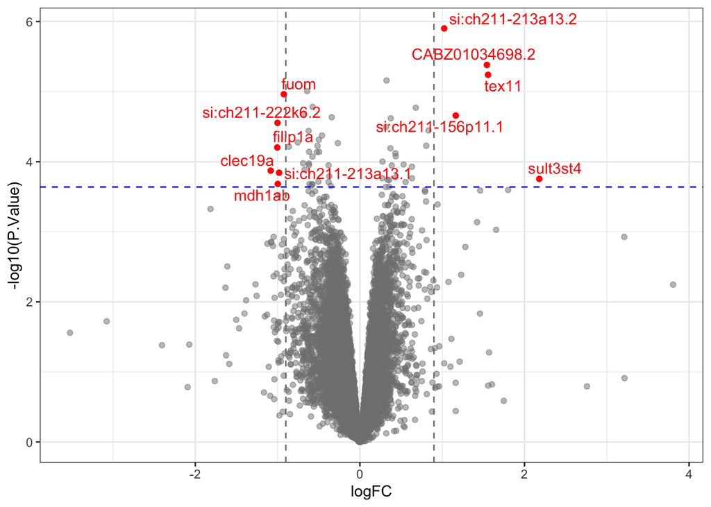

Volcano plot highlighting DE genes. Genes were considered as DE if receiving a q-value < 0.05 and with logFC beyond the range $\pm 0.9$. Genes indicated in red below the blue line recieved a q-value < 0.1 and are of potential interest.

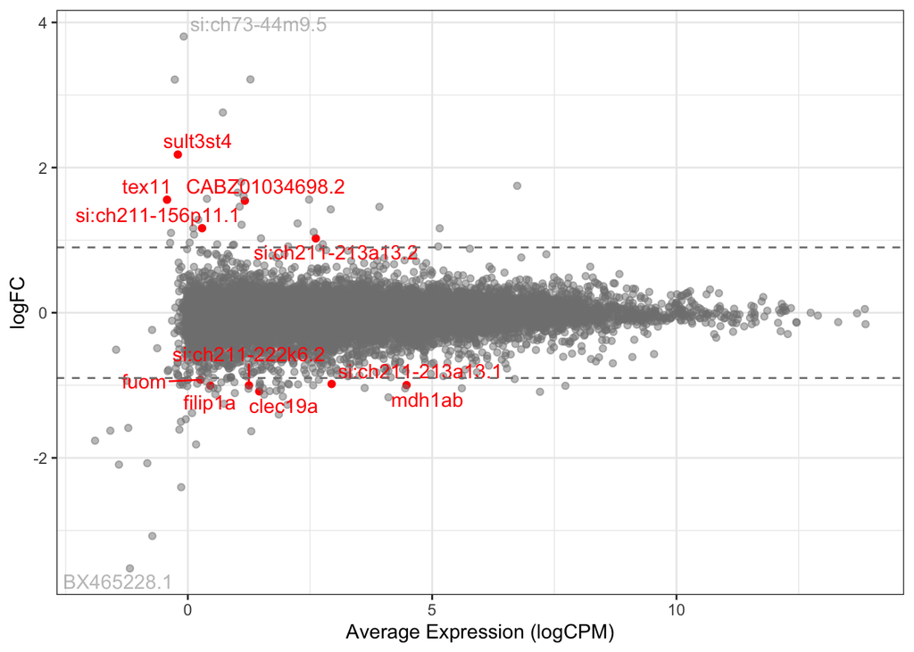

logFC plotted against expression level with significant DE genes shown in red.

The 11 genes considered as DE using an FDR of 0.05 and logFC beyond the range $\pm 0.9$ were then inspected to confirm that the counts support their inclusion as DE.

Top 30 results from DGE analysis. FDR indicates the Benjamini-Hochberg FDR, whilst q-values represent the Storey FDR.

| ensembl_gene_id | description | external_gene_name | logFC | AveExpr | t | P.Value | FDR | q |
| --- | --- | --- | --- | --- | --- | --- | --- | --- |
| ENSDARG00000099511 | NUL | CABZ01034698.2 | 1.544 | 1.167 | 7.755 | 4.154e-06 | 0.03364 | 0.02146 |
| ENSDARG00000093024 | si:ch211-213a13.2 | si:ch211-213a13.2 | 1.024 | 2.619 | 7.116 | 1.252e-06 | 0.02428 | 0.01549 |
| ENSDARG00000076805 | leukocyte receptor cluster (LRC) member 8 | leng8 | 0.3238 | 8.013 | 7.38 | 6.937e-06 | 0.03364 | 0.02146 |
| ENSDARG00000078995 | testis expressed 11 | tex11 | 1.557 | -0.4252 | 6.279 | 5.747e-06 | 0.03364 | 0.02146 |
| ENSDARG00000093997 | si:dkey-9i23.15 | si:dkey-9i23.15 | -0.6411 | 1.961 | -5.998 | 9.842e-06 | 0.03522 | 0.02248 |
| ENSDARG00000039422 | fucose mutarotase | fuom | -0.9243 | 0.2572 | -5.946 | 1.09e-05 | 0.03522 | 0.02248 |
| ENSDARG00000094466 | si:ch73-199e17.1 | si:ch73-199e17.1 | -0.575 | 2.486 | -5.735 | 1.652e-05 | 0.03883 | 0.02478 |
| ENSDARG00000076439 | protein phosphatase 4, catalytic subunit b | ppp4cb | -0.342 | 3.99 | -6.546 | 2.319e-05 | 0.03883 | 0.02478 |
| ENSDARG00000037613 | galectin 8b | lgals8b | 0.679 | 1.213 | 5.722 | 1.695e-05 | 0.03883 | 0.02478 |
| ENSDARG00000063195 | PX domain containing serine/threonine kinase | pxk | 0.3753 | 6.012 | 6.522 | 2.402e-05 | 0.03883 | 0.02478 |
| ENSDARG00000011072 | DEAD/H (Asp-Glu-Ala-Asp/His) box helicase 11 | ddx11 | -0.693 | 0.6051 | -5.609 | 2.125e-05 | 0.03883 | 0.02478 |
| ENSDARG00000098754 | si:ch211-156p11.1 | si:ch211-156p11.1 | 1.165 | 0.2919 | 5.593 | 2.194e-05 | 0.03883 | 0.02478 |
| ENSDARG00000041533 | coiled-coil domain containing 130 | ccdc130 | 0.3176 | 3.453 | 6.335 | 3.193e-05 | 0.04404 | 0.02811 |
| ENSDARG00000087046 | si:ch211-222k6.2 | si:ch211-222k6.2 | -1.001 | 1.251 | -5.474 | 2.789e-05 | 0.04162 | 0.02656 |
| ENSDARG00000054510 | adrenoceptor beta 2, surface b | adrb2b | -0.6233 | 1.223 | -6.25 | 3.633e-05 | 0.04404 | 0.02811 |
| ENSDARG00000070140 | zgc:154169 | RETSAT | 0.8336 | 0.2597 | 5.352 | 3.581e-05 | 0.04404 | 0.02811 |
| ENSDARG00000042018 | four and a half LIM domains 2a | fhl2a | -0.4599 | 4.902 | -5.271 | 4.231e-05 | 0.04827 | 0.03081 |
| ENSDARG00000042876 | ABRA C-terminal like | abracl | -0.4989 | 2.961 | -6.064 | 4.852e-05 | 0.04998 | 0.0319 |
| ENSDARG00000076870 | piezo-type mechanosensitive ion channel component 1 | piezo1 | -0.2678 | 4.533 | -5.993 | 5.43e-05 | 0.04998 | 0.0319 |
| ENSDARG00000057128 | hydroxyacyl-CoA dehydrogenase trifunctional multienzyme complex subunit alpha a | hadhaa | -0.7543 | 4.073 | -5.162 | 5.317e-05 | 0.04998 | 0.0319 |
| ENSDARG00000060498 | tumor necrosis factor receptor superfamily, member 9a | tnfrsf9a | -0.5149 | 0.6015 | -5.936 | 5.942e-05 | 0.04998 | 0.0319 |
| ENSDARG00000078419 | filamin A interacting protein 1a | filip1a | -1.004 | 0.4612 | -5.902 | 6.262e-05 | 0.04998 | 0.0319 |
| ENSDARG00000104899 | si:dkey-242k1.4 | CR931813.2 | 0.806 | 1.98 | 5.11 | 5.919e-05 | 0.04998 | 0.0319 |
| ENSDARG00000037427 | si:ch211-39a7.1 | si:ch211-39a7.1 | 0.3708 | 1.744 | 5.885 | 6.442e-05 | 0.04998 | 0.0319 |
| ENSDARG00000077068 | si:ch211-11p18.6 | si:ch211-11p18.6 | -0.8625 | 3.513 | -5.096 | 6.094e-05 | 0.04998 | 0.0319 |
| ENSDARG00000097485 | cilia and flagella associated protein 99 | cfap99 | -0.617 | 0.1869 | -5.017 | 7.208e-05 | 0.05057 | 0.03227 |
| ENSDARG00000010977 | RAB34, member RAS oncogene family b | rab34b | -0.4948 | 0.2501 | -5.014 | 7.242e-05 | 0.05057 | 0.03227 |
| ENSDARG00000042285 | ATPase phospholipid transporting 8B3 | atp8b3 | -0.5232 | 2.215 | -5.011 | 7.3e-05 | 0.05057 | 0.03227 |
| ENSDARG00000099917 | zinc finger protein 1005 | znf1005 | 0.4307 | 0.525 | 4.993 | 7.572e-05 | 0.05064 | 0.03232 |
| ENSDARG00000097825 | uncharacterized LOC100535512 | BX465227.1 | 0.4358 | 3.165 | 4.946 | 8.364e-05 | 0.05305 | 0.03385 |

###GO(Gene Ontology) analysis

The first step here is to map the Ensembl zebrafish gene IDs to Human Entrez gene IDs.

```r
ens2Entrez <- file.path("../R/mart_export.tsv") %>%
    read_tsv()
goSummaries <- url("https://uofabioinformaticshub.github.io/summaries2GO/data/goSummaries.RDS") %>%
  readRDS()
```

```r
minLFC <- 0.8
de <- deGenes %>%
    dplyr::filter(q < 0.05 & abs(logFC) > minLFC) %>%
    dplyr::select(`Gene stable ID` = ensembl_gene_id) %>%
    left_join(ens2Entrez) %>%
    dplyr::filter(!is.na(`NCBI gene ID`)) %>%
    .[["NCBI gene ID"]] %>%
    unique()
uv <- deGenes %>%
    dplyr::select(`Gene stable ID` = ensembl_gene_id) %>%
    left_join(ens2Entrez) %>%
    dplyr::filter(!is.na(`NCBI gene ID`)) %>%
    .[["NCBI gene ID"]] %>%
    unique()
```

```r
goResults <- goana(de = de, universe = uv, species = "Hs") %>%
    rownames_to_column("id") %>%
    left_join(goSummaries) %>%
    as_tibble()
```

```r
goResults %>%
    dplyr::filter(shortest_path > 3, DE > 1) %>%
    arrange(P.DE) %>%
    mutate(adjP = p.adjust(P.DE, "bonferroni")) %>%
    dplyr::filter(adjP < 0.05) %>%
    pander(caption = "GO Terms potentially enriched in the set of differentially expressed genes")
```

GO Terms potentially enriched in the set of differentially expressed genes

| id | Term | Ont | N | DE | P.DE | shortest_path | longest_path | terminal_node | ontology | adjP |
| --- | --- | --- | --- | --- | --- | --- | --- | --- | --- | --- |
| GO:0003677 | DNA binding | MF | 1,431 | 20 | 4.54e-13 | 4 | 4 | FALSE | MF | 3.814e-11 |
| GO:0004062 | aryl sulfotransferase activity | MF | 7 | 4 | 7.536e-10 | 5 | 5 | TRUE | MF | 6.331e-08 |
| GO:0006355 | regulation of transcription, DNA-templated | BP | 2,253 | 20 | 2.112e-09 | 5 | 10 | FALSE | BP | 1.774e-07 |
| GO:1903506 | regulation of nucleic acid-templated transcription | BP | 2,306 | 20 | 3.219e-09 | 6 | 9 | FALSE | BP | 2.704e-07 |
| GO:2001141 | regulation of RNA biosynthetic process | BP | 2,312 | 20 | 3.374e-09 | 5 | 8 | FALSE | BP | 2.834e-07 |
| GO:0006351 | transcription, DNA-templated | BP | 2,404 | 20 | 6.822e-09 | 5 | 9 | FALSE | BP | 5.73e-07 |
| GO:0097659 | nucleic acid-templated transcription | BP | 2,445 | 20 | 9.245e-09 | 6 | 8 | FALSE | BP | 7.766e-07 |
| GO:0032774 | RNA biosynthetic process | BP | 2,456 | 20 | 1.002e-08 | 5 | 7 | FALSE | BP | 8.417e-07 |
| GO:0051252 | regulation of RNA metabolic process | BP | 2,471 | 20 | 1.118e-08 | 4 | 7 | FALSE | BP | 9.388e-07 |
| GO:0006357 | regulation of transcription by RNA polymerase II | BP | 1,677 | 17 | 1.255e-08 | 6 | 11 | FALSE | BP | 1.054e-06 |
| GO:2000112 | regulation of cellular macromolecule biosynthetic process | BP | 2,560 | 20 | 2.103e-08 | 5 | 6 | FALSE | BP | 1.767e-06 |
| GO:0010556 | regulation of macromolecule biosynthetic process | BP | 2,659 | 20 | 4.128e-08 | 4 | 5 | FALSE | BP | 3.467e-06 |
| GO:0006366 | transcription by RNA polymerase II | BP | 1,815 | 17 | 4.186e-08 | 6 | 10 | FALSE | BP | 3.517e-06 |
| GO:0019219 | regulation of nucleobase-containing compound metabolic process | BP | 2,696 | 20 | 5.271e-08 | 4 | 5 | FALSE | BP | 4.428e-06 |
| GO:0031326 | regulation of cellular biosynthetic process | BP | 2,794 | 20 | 9.888e-08 | 4 | 5 | FALSE | BP | 8.306e-06 |
| GO:0046872 | metal ion binding | MF | 2,883 | 20 | 1.712e-07 | 4 | 4 | FALSE | MF | 1.438e-05 |
| GO:0034654 | nucleobase-containing compound biosynthetic process | BP | 2,884 | 20 | 1.723e-07 | 4 | 5 | FALSE | BP | 1.447e-05 |
| GO:0034035 | purine ribonucleoside bisphosphate metabolic process | BP | 23 | 4 | 1.859e-07 | 6 | 9 | FALSE | BP | 1.562e-05 |
| GO:0050427 | 3’-phosphoadenosine 5’-phosphosulfate metabolic process | BP | 23 | 4 | 1.859e-07 | 4 | 10 | FALSE | BP | 1.562e-05 |
| GO:0018130 | heterocycle biosynthetic process | BP | 2,937 | 20 | 2.366e-07 | 4 | 4 | FALSE | BP | 1.987e-05 |
| GO:0019438 | aromatic compound biosynthetic process | BP | 2,948 | 20 | 2.525e-07 | 4 | 4 | FALSE | BP | 2.121e-05 |
| GO:0010468 | regulation of gene expression | BP | 2,981 | 20 | 3.063e-07 | 4 | 5 | FALSE | BP | 2.573e-05 |
| GO:1901362 | organic cyclic compound biosynthetic process | BP | 3,057 | 20 | 4.735e-07 | 4 | 4 | FALSE | BP | 3.978e-05 |
| GO:0044271 | cellular nitrogen compound biosynthetic process | BP | 3,425 | 21 | 5.307e-07 | 4 | 4 | FALSE | BP | 4.458e-05 |
| GO:0090304 | nucleic acid metabolic process | BP | 3,475 | 21 | 6.898e-07 | 4 | 5 | FALSE | BP | 5.794e-05 |
| GO:0016070 | RNA metabolic process | BP | 3,128 | 20 | 7.031e-07 | 5 | 6 | FALSE | BP | 5.906e-05 |
| GO:0034645 | cellular macromolecule biosynthetic process | BP | 3,312 | 20 | 1.864e-06 | 4 | 5 | FALSE | BP | 0.0001566 |
| GO:0008146 | sulfotransferase activity | MF | 40 | 4 | 1.868e-06 | 4 | 4 | FALSE | MF | 0.0001569 |
| GO:0006068 | ethanol catabolic process | BP | 12 | 3 | 2.296e-06 | 5 | 7 | FALSE | BP | 0.0001928 |
| GO:0006584 | catecholamine metabolic process | BP | 44 | 4 | 2.757e-06 | 4 | 6 | FALSE | BP | 0.0002316 |
| GO:0009712 | catechol-containing compound metabolic process | BP | 44 | 4 | 2.757e-06 | 5 | 5 | FALSE | BP | 0.0002316 |
| GO:0051923 | sulfation | BP | 13 | 3 | 2.98e-06 | 4 | 4 | FALSE | BP | 0.0002503 |
| GO:0009059 | macromolecule biosynthetic process | BP | 3,428 | 20 | 3.333e-06 | 4 | 4 | FALSE | BP | 0.0002799 |
| GO:0034310 | primary alcohol catabolic process | BP | 15 | 3 | 4.726e-06 | 5 | 6 | FALSE | BP | 0.000397 |
| GO:0010467 | gene expression | BP | 3,695 | 20 | 1.16e-05 | 4 | 4 | FALSE | BP | 0.0009748 |
| GO:0006067 | ethanol metabolic process | BP | 20 | 3 | 1.175e-05 | 5 | 6 | FALSE | BP | 0.000987 |
| GO:0047894 | flavonol 3-sulfotransferase activity | MF | 3 | 2 | 1.495e-05 | 5 | 5 | TRUE | MF | 0.001255 |
| GO:0034308 | primary alcohol metabolic process | BP | 67 | 4 | 1.501e-05 | 4 | 5 | FALSE | BP | 0.001261 |
| GO:0018958 | phenol-containing compound metabolic process | BP | 78 | 4 | 2.746e-05 | 4 | 4 | FALSE | BP | 0.002307 |
| GO:0017001 | antibiotic catabolic process | BP | 32 | 3 | 5.019e-05 | 4 | 5 | FALSE | BP | 0.004216 |
| GO:0046164 | alcohol catabolic process | BP | 42 | 3 | 0.0001144 | 4 | 5 | FALSE | BP | 0.00961 |
| GO:0033865 | nucleoside bisphosphate metabolic process | BP | 116 | 4 | 0.0001298 | 5 | 7 | FALSE | BP | 0.01091 |
| GO:0033875 | ribonucleoside bisphosphate metabolic process | BP | 116 | 4 | 0.0001298 | 6 | 8 | FALSE | BP | 0.01091 |
| GO:0034032 | purine nucleoside bisphosphate metabolic process | BP | 116 | 4 | 0.0001298 | 5 | 8 | FALSE | BP | 0.01091 |
| GO:1901616 | organic hydroxy compound catabolic process | BP | 52 | 3 | 0.0002169 | 4 | 4 | FALSE | BP | 0.01822 |
| GO:0005634 | nucleus | CC | 4,922 | 21 | 0.0002755 | 4 | 7 | FALSE | CC | 0.02314 |

###GO analysis plot

```r
go2plot <- goResults %>%
    dplyr::filter(shortest_path > 4, DE > 1) %>%
    arrange(P.DE) %>%
    mutate(adjP = p.adjust(P.DE, "bonferroni")) %>%
    dplyr::filter(adjP < 0.05) %>%
  .[["id"]] %>%
  sapply(get, envir = org.Hs.egGO2ALLEGS, simplify = FALSE) %>%
  lapply(intersect, de) %>%
  lapply(unique)
```

Both the GO terms and genes were setup as tibble objects for easier manipulation.

```r
pathwaysGO <- tibble(label = names(go2plot))
genesGO <- go2plot %>%
  unlist() %>%
  unique() %>%
  as.character() %>%
  enframe(name = NULL, value = "label")
```

Next we need to setup the nodes and edges

```r
nodesGO <- pathwaysGO %>%
  bind_rows(genesGO) %>%
  rowid_to_column("id")
edgesGO <- ldply(go2plot, as.data.frame) %>%
  as_tibble() %>%
  set_colnames(c("pathway", "gene")) %>%
  mutate_all(as.character) %>%
  left_join(nodesGO, by = c("pathway" = "label")) %>%
  dplyr::rename(from = id) %>%
  left_join(nodesGO, by = c("gene" = "label")) %>%
  dplyr::rename(to = id) %>%
  dplyr::select(from, to)
```

```r
tidyGO <- tbl_graph(
  nodes = nodesGO,
  edges = edgesGO,
  directed = FALSE
) %>%
  activate(nodes) %>%
  mutate(
    Term = Term(label),
    pathways = case_when(
      label %in% names(go2plot) ~ Term
    ),
    pathways = str_trunc(pathways, 50),
    genes = case_when(
      !label %in% names(go2plot) ~ label
    ),
    # Make the GO terms much larger than the genes
    size = case_when(
      !is.na(pathways) ~ 1000,
      is.na(pathways) ~ 1000
    ),
    # Define colours for genes & GO terms
    colour = case_when(
      label %in% names(go2plot) ~ rainbow(max(id))[id],
      !label %in% names(go2plot) ~ "black"
    )
  ) %>%
  activate(edges) %>%
  mutate(
    colour = case_when(
      from <= length(go2plot) ~ rainbow(max(to))[from]
    )
  )
```

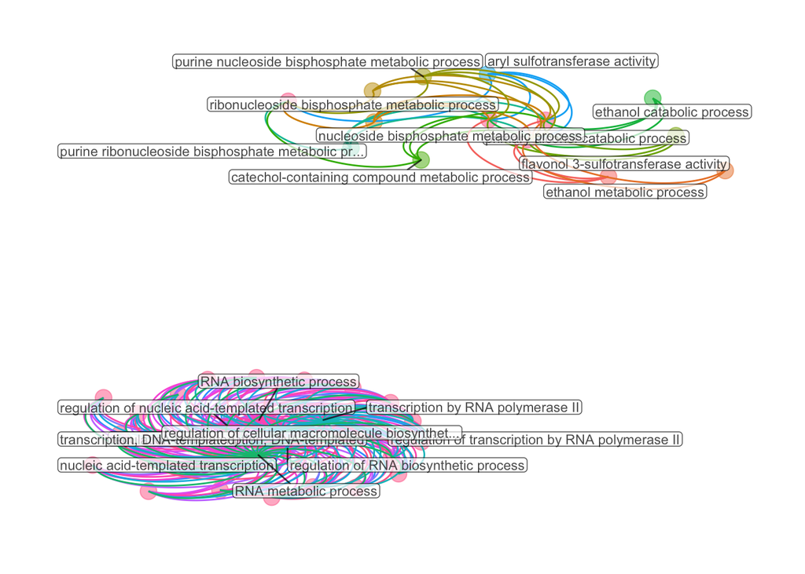

```r
set.seed(14)
ggraph(tidyGO, layout = "fr") +
  geom_node_point(
    aes(size = size, colour = colour),
    alpha = 0.5
    ) +
  geom_edge_arc(
    aes(colour = colour)
  ) +
  geom_node_label(
     aes(label = pathways),
  repel = TRUE,
    size = 3,
    alpha = 0.7,
    label.padding = 0.1
  ) +
  theme_graph() +
  theme(
    legend.position = "none"
  )
```

###Gene Set Enrichment analysis (GSEA)

```r
# Load id conversion file
idConvert <- read_csv2("../files/zf2human_withEntrezIDs.csv") %>%
  dplyr::select(Geneid = zfID, EntrezID = Entrez) %>%
  mutate(EntrezID = as.character(EntrezID))
# Create function to convert ids
convertHsEG2Dr <- function(ids, df = idConvert){
  dplyr::filter(df, EntrezID %in% ids)$Geneid
}
# Conversion of zebrafish ensembl ID to zebrafish symbol, for plotting on network analyses
idConvertSymbol <- read_csv2("../files/zf2human_withEntrezIDs.csv") %>%
  dplyr::select(label = zfID, symbol = zfName) %>%
  na.omit() %>%
  unique()
```

```r
# Create named vector of gene level statistics
ranks <- deGenes %>%
  mutate(stat = -sign(logFC) * log10(P.Value)) %>%
  dplyr::arrange(desc(stat)) %>%
  with(structure(stat, names = ensembl_gene_id))
```

```r
# Import hallmark human gene genesets and tidy gene set names
# .gmt files downloaded from:
# http://software.broadinstitute.org/gsea/downloads.jsp
# http://data.wikipathways.org/20190610/
hallmark <- gmtPathways("../files/h.all.v6.2.entrez.gmt") %>%
  mclapply(convertHsEG2Dr, mc.cores = 4) %>%
  set_names(str_remove_all(names(.), "HALLMARK_"))
kegg <- gmtPathways("../files/c2.cp.kegg.v6.2.entrez.gmt") %>%
  mclapply(convertHsEG2Dr, mc.cores = 4) %>%
  set_names(str_remove_all(names(.), "KEGG_"))
wiki <- gmtPathways("../files/wikipathways-20190610-gmt-Homo_sapiens.gmt") %>%
  mclapply(convertHsEG2Dr, mc.cores = 4) %>%
  set_names(str_remove_all(names(.), "%.+"))
```

### Hallmark pathways

```r
# Set seed to enable reproducibility
set.seed(22)
# Run GSEA for hallmark
fgseaHallmark <- fgsea(hallmark, ranks, nperm=1e5) %>%
  as_tibble() %>%
  dplyr::rename(FDR = padj) %>%
  mutate(padj = p.adjust(pval, "bonferroni")) %>%
  dplyr::arrange(pval)
# Create an object of pathways with adjusted p-value < 0.05 for construction of network diagrams. This should be done differently next time, but too much work has been done to change it now.
fgseaHallmarkTop <- fgseaHallmark %>%
  dplyr::filter(padj < 0.05)
fgseaHallmarkTop %>%
  dplyr::select(-leadingEdge, -nMoreExtreme) %>%
  pander(
    style = "rmarkdown",
    split.tables = Inf,
    justify = "lrrrrrr",
    caption = paste(
      "The", nrow(.), "most significantly enriched Hallmark pathways.",
      "This corresponds to an FDR of", percent(max(.$FDR)))
  )
```

The 18 most significantly enriched Hallmark pathways. This corresponds to an FDR of 0.162%

| pathway | pval | FDR | ES | NES | size | padj |
| --- | --- | --- | --- | --- | --- | --- |
| MYOGENESIS | 1.555e-05 | 6.577e-05 | -0.4076 | -1.788 | 278 | 0.0007777 |
| XENOBIOTIC_METABOLISM | 1.556e-05 | 6.577e-05 | -0.3916 | -1.719 | 280 | 0.0007782 |
| EPITHELIAL_MESENCHYMAL_TRANSITION | 1.578e-05 | 6.577e-05 | -0.3948 | -1.704 | 238 | 0.000789 |
| MTORC1_SIGNALING | 1.585e-05 | 6.577e-05 | -0.5094 | -2.192 | 232 | 0.0007925 |
| GLYCOLYSIS | 1.586e-05 | 6.577e-05 | -0.4492 | -1.932 | 230 | 0.0007931 |
| ESTROGEN_RESPONSE_LATE | 1.587e-05 | 6.577e-05 | -0.4219 | -1.811 | 226 | 0.0007935 |
| ESTROGEN_RESPONSE_EARLY | 1.588e-05 | 6.577e-05 | -0.4045 | -1.733 | 222 | 0.0007942 |
| OXIDATIVE_PHOSPHORYLATION | 1.591e-05 | 6.577e-05 | -0.512 | -2.191 | 220 | 0.0007957 |
| MYC_TARGETS_V1 | 1.593e-05 | 6.577e-05 | -0.4289 | -1.834 | 218 | 0.0007966 |
| G2M_CHECKPOINT | 1.597e-05 | 6.577e-05 | -0.5007 | -2.134 | 212 | 0.0007984 |
| FATTY_ACID_METABOLISM | 1.605e-05 | 6.577e-05 | -0.4997 | -2.113 | 198 | 0.0008025 |
| E2F_TARGETS | 1.61e-05 | 6.577e-05 | -0.5367 | -2.252 | 185 | 0.000805 |
| CHOLESTEROL_HOMEOSTASIS | 1.71e-05 | 6.577e-05 | -0.544 | -2.049 | 86 | 0.000855 |
| COMPLEMENT | 6.333e-05 | 0.0002262 | -0.3787 | -1.632 | 235 | 0.003166 |
| COAGULATION | 9.861e-05 | 0.0003287 | -0.4198 | -1.718 | 151 | 0.00493 |
| INTERFERON_GAMMA_RESPONSE | 0.000112 | 0.0003501 | -0.3843 | -1.632 | 205 | 0.005601 |
| UV_RESPONSE_UP | 0.0003064 | 0.0009011 | -0.3795 | -1.594 | 187 | 0.01532 |
| IL2_STAT5_SIGNALING | 0.0005832 | 0.00162 | -0.3551 | -1.535 | 242 | 0.02916 |

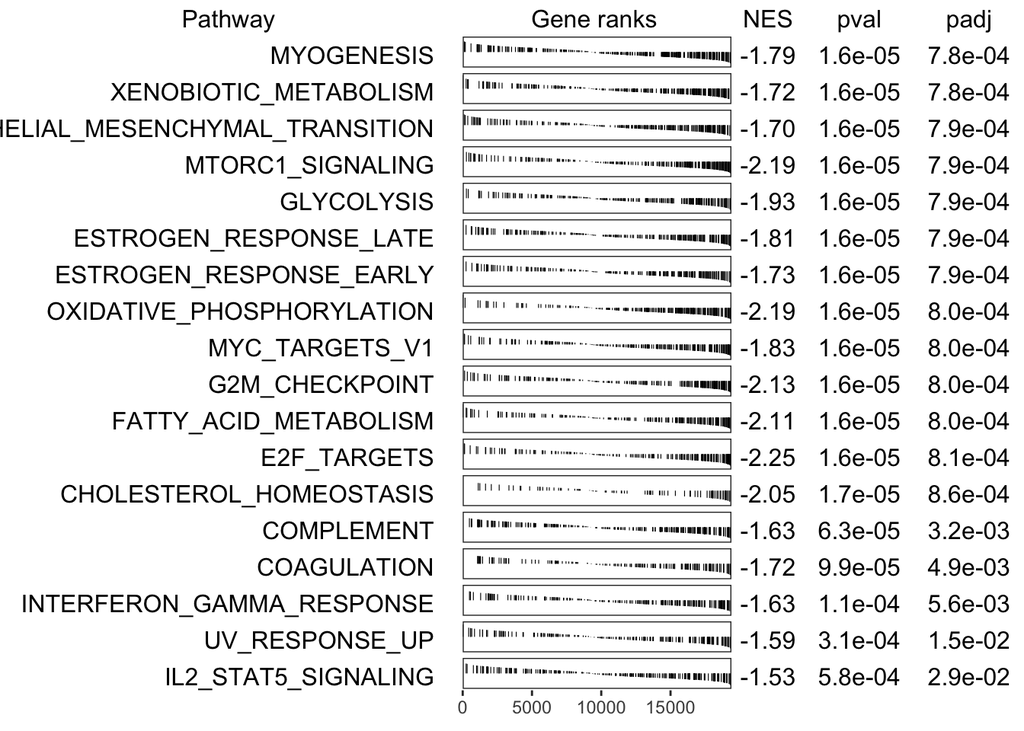

```r
# Make a table plot of significant Hallmark pathways
if (interactive()) grid::grid.newpage()
plotGseaTable(
  hallmark[fgseaHallmarkTop$pathway], ranks, fgseaHallmark, gseaParam = 0.5
)
```

### KEGG pathways

```r
# Set seed to enable reproducibility
set.seed(22)
# Run GSEA for KEGG
fgseaKEGG <- fgsea(kegg, ranks, nperm=1e5) %>%
  as_tibble() %>%
  dplyr::rename(FDR = padj) %>%
  mutate(padj = p.adjust(pval, "bonferroni")) %>%
  dplyr::arrange(pval)
# Create an object of pathways with adjusted p-value < 0.05 for construction of network diagrams. This should be done differently next time, but too much work has been done to change it now.
fgseaKEGGTop <- fgseaKEGG %>%
  dplyr::filter(padj < 0.05)
fgseaKEGGTop %>%
  dplyr::select(-leadingEdge, -nMoreExtreme) %>%
  pander(
    style = "rmarkdown",
    split.tables = Inf,
    justify = "lrrrrrr",
    caption = paste(
      "The", nrow(.), "most significantly enriched KEGG pathways.",
      "This corresponds to an FDR of", percent(max(.$FDR)))
  )
```

The 33 most significantly enriched KEGG pathways. This corresponds to an FDR of 0.149%

| pathway | pval | FDR | ES | NES | size | padj |
| --- | --- | --- | --- | --- | --- | --- |
| METABOLISM_OF_XENOBIOTICS_BY_CYTOCHROME_P450 | 1.476e-05 | 0.0001602 | -0.4512 | -2.064 | 438 | 0.002744 |
| DRUG_METABOLISM_CYTOCHROME_P450 | 1.479e-05 | 0.0001602 | -0.4362 | -1.993 | 431 | 0.002751 |
| RETINOL_METABOLISM | 1.479e-05 | 0.0001602 | -0.4035 | -1.842 | 429 | 0.002752 |
| DRUG_METABOLISM_OTHER_ENZYMES | 1.522e-05 | 0.0001602 | -0.4561 | -2.037 | 333 | 0.002832 |
| STEROID_HORMONE_BIOSYNTHESIS | 1.529e-05 | 0.0001602 | -0.4755 | -2.117 | 321 | 0.002844 |
| STARCH_AND_SUCROSE_METABOLISM | 1.549e-05 | 0.0001602 | -0.5083 | -2.236 | 285 | 0.002881 |
| PORPHYRIN_AND_CHLOROPHYLL_METABOLISM | 1.55e-05 | 0.0001602 | -0.4883 | -2.147 | 284 | 0.002883 |
| PENTOSE_AND_GLUCURONATE_INTERCONVERSIONS | 1.557e-05 | 0.0001602 | -0.4949 | -2.165 | 269 | 0.002896 |
| ASCORBATE_AND_ALDARATE_METABOLISM | 1.557e-05 | 0.0001602 | -0.5012 | -2.191 | 267 | 0.002896 |
| CYTOKINE_CYTOKINE_RECEPTOR_INTERACTION | 1.558e-05 | 0.0001602 | -0.4026 | -1.759 | 266 | 0.002898 |
| ALZHEIMERS_DISEASE | 1.624e-05 | 0.0001602 | -0.4419 | -1.835 | 170 | 0.003021 |
| OXIDATIVE_PHOSPHORYLATION | 1.659e-05 | 0.0001602 | -0.5554 | -2.231 | 131 | 0.003086 |
| PARKINSONS_DISEASE | 1.669e-05 | 0.0001602 | -0.5216 | -2.079 | 124 | 0.003104 |
| GLYCOLYSIS_GLUCONEOGENESIS | 1.692e-05 | 0.0001602 | -0.5638 | -2.175 | 99 | 0.003147 |
| PYRIMIDINE_METABOLISM | 1.698e-05 | 0.0001602 | -0.5023 | -1.924 | 95 | 0.003159 |
| ECM_RECEPTOR_INTERACTION | 1.7e-05 | 0.0001602 | -0.5382 | -2.049 | 91 | 0.003162 |
| FATTY_ACID_METABOLISM | 1.732e-05 | 0.0001602 | -0.6906 | -2.523 | 71 | 0.003221 |
| GLUTATHIONE_METABOLISM | 1.748e-05 | 0.0001602 | -0.6586 | -2.361 | 64 | 0.003251 |
| NITROGEN_METABOLISM | 1.793e-05 | 0.0001602 | -0.703 | -2.234 | 35 | 0.003335 |
| DNA_REPLICATION | 1.803e-05 | 0.0001602 | -0.7349 | -2.257 | 30 | 0.003353 |
| BETA_ALANINE_METABOLISM | 1.809e-05 | 0.0001602 | -0.7223 | -2.183 | 28 | 0.003365 |
| CELL_CYCLE | 3.345e-05 | 0.0002828 | -0.4888 | -1.931 | 116 | 0.006221 |
| TYROSINE_METABOLISM | 5.196e-05 | 0.0004202 | -0.5284 | -1.93 | 71 | 0.009664 |
| ARGININE_AND_PROLINE_METABOLISM | 6.928e-05 | 0.0005369 | -0.5209 | -1.903 | 71 | 0.01289 |
| HEMATOPOIETIC_CELL_LINEAGE | 8.344e-05 | 0.0006208 | -0.4398 | -1.749 | 122 | 0.01552 |
| ALANINE_ASPARTATE_AND_GLUTAMATE_METABOLISM | 8.887e-05 | 0.0006358 | -0.6008 | -1.977 | 41 | 0.01653 |
| TERPENOID_BACKBONE_BIOSYNTHESIS | 0.000111 | 0.0007645 | -0.772 | -2.003 | 15 | 0.02064 |
| GLYCINE_SERINE_AND_THREONINE_METABOLISM | 0.0001258 | 0.0008358 | -0.6358 | -1.994 | 33 | 0.0234 |
| PROXIMAL_TUBULE_BICARBONATE_RECLAMATION | 0.0001947 | 0.001249 | -0.5614 | -1.891 | 46 | 0.03622 |
| BUTANOATE_METABOLISM | 0.0002129 | 0.00132 | -0.5613 | -1.882 | 45 | 0.03959 |
| BIOSYNTHESIS_OF_UNSATURATED_FATTY_ACIDS | 0.0002549 | 0.001491 | -0.6706 | -1.935 | 23 | 0.0474 |
| PEROXISOME | 0.0002566 | 0.001491 | -0.4645 | -1.752 | 86 | 0.04773 |
| VALINE_LEUCINE_AND_ISOLEUCINE_DEGRADATION | 0.0002645 | 0.001491 | -0.5397 | -1.856 | 51 | 0.04919 |

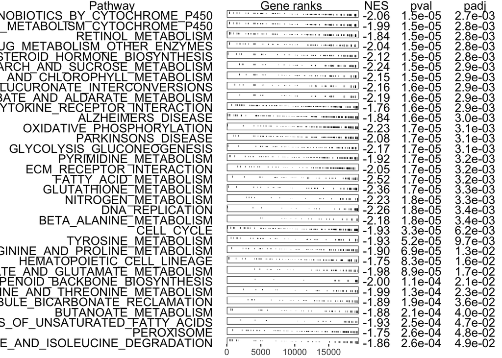

```r
# Make a table plot of significant KEGG pathways
if (interactive()) grid::grid.newpage()
plotGseaTable(
  kegg[fgseaKEGGTop$pathway], ranks, fgseaKEGG, gseaParam = 0.5
)
```

### WikiPathways

```r
# Set seed to enable reproducibility
set.seed(22)
# Run GSEA for WikiPathways
fgseaWiki <- fgsea(wiki, ranks, nperm=1e5) %>%
  as_tibble() %>%
  dplyr::rename(FDR = padj) %>%
  mutate(padj = p.adjust(pval, "bonferroni")) %>%
  dplyr::arrange(pval)
# Create an object of pathways with adjusted p-value < 0.05 for construction of network diagrams. This should be done differently next time, but too much work has been done to change it now.
fgseaWikiTop <- fgseaWiki %>%
  dplyr::filter(padj < 0.05)
fgseaWikiTop %>%
  dplyr::select(-leadingEdge, -nMoreExtreme) %>%
  pander(
    style = "rmarkdown",
    split.tables = Inf,
    justify = "lrrrrrr",
    caption = paste(
      "The", nrow(.), "most significantly enriched Wiki pathways.",
      "This corresponds to an FDR of", percent(max(.$FDR)))
  )
```

The 21 most significantly enriched Wiki pathways. This corresponds to an FDR of 0.234%

| pathway | pval | FDR | ES | NES | size | padj |
| --- | --- | --- | --- | --- | --- | --- |
| Metapathway biotransformation Phase I and II | 1.426e-05 | 0.0007823 | -0.361 | -1.688 | 585 | 0.007485 |
| Nuclear Receptors Meta-Pathway | 1.432e-05 | 0.0007823 | -0.398 | -1.856 | 564 | 0.007515 |
| PI3K-Akt Signaling Pathway | 1.496e-05 | 0.0007823 | -0.342 | -1.547 | 384 | 0.007856 |
| Focal Adhesion-PI3K-Akt-mTOR-signaling pathway | 1.498e-05 | 0.0007823 | -0.3447 | -1.558 | 380 | 0.007866 |
| NRF2 pathway | 1.526e-05 | 0.0007823 | -0.5152 | -2.291 | 317 | 0.008012 |
| Glucuronidation | 1.547e-05 | 0.0007823 | -0.5055 | -2.218 | 278 | 0.00812 |
| Breast cancer pathway | 1.607e-05 | 0.0007823 | -0.4186 | -1.753 | 183 | 0.008438 |
| Amino Acid metabolism | 1.678e-05 | 0.0007823 | -0.5236 | -2.045 | 109 | 0.00881 |
| Electron Transport Chain (OXPHOS system in mitochondria) | 1.688e-05 | 0.0007823 | -0.5679 | -2.185 | 98 | 0.008863 |
| Retinoblastoma Gene in Cancer | 1.709e-05 | 0.0007823 | -0.5742 | -2.148 | 82 | 0.008973 |
| G1 to S cell cycle control | 1.743e-05 | 0.0007823 | -0.6259 | -2.216 | 60 | 0.009153 |
| DNA Replication | 1.788e-05 | 0.0007823 | -0.7003 | -2.225 | 35 | 0.009387 |
| Genes related to primary cilium development (based on CRISPR) | 2.421e-05 | 0.0009775 | 0.5284 | 2.08 | 87 | 0.01271 |
| Cell Cycle | 3.354e-05 | 0.001221 | -0.4872 | -1.91 | 112 | 0.01761 |
| Oxidative phosphorylation | 3.489e-05 | 0.001221 | -0.5915 | -2.1 | 61 | 0.01832 |
| Pyrimidine metabolism | 5.162e-05 | 0.001609 | -0.5254 | -1.93 | 74 | 0.0271 |
| Glycolysis and Gluconeogenesis | 5.215e-05 | 0.001609 | -0.5679 | -2.023 | 62 | 0.02738 |
| Cholesterol Biosynthesis Pathway | 5.517e-05 | 0.001609 | -0.7781 | -2.053 | 16 | 0.02897 |
| Epithelial to mesenchymal transition in colorectal cancer | 8.052e-05 | 0.002225 | -0.4053 | -1.693 | 179 | 0.04227 |
| Trans-sulfuration and one carbon metabolism | 8.902e-05 | 0.002337 | -0.6258 | -2.036 | 39 | 0.04674 |
| Splicing factor NOVA regulated synaptic proteins | 9.38e-05 | 0.002345 | 0.5232 | 1.928 | 60 | 0.04924 |

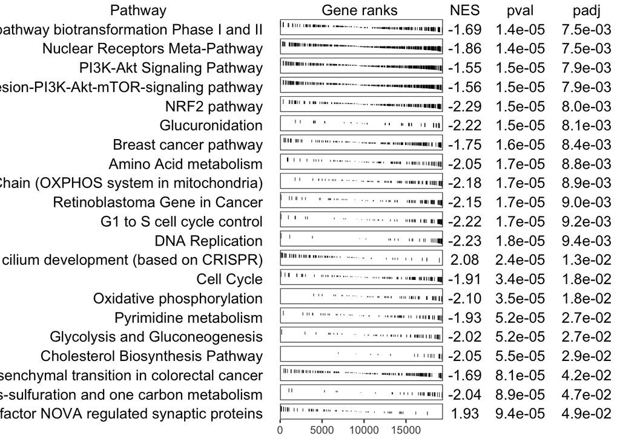

```r
# Make a table plot of significant WikiPathways pathways
if (interactive()) grid::grid.newpage()
plotGseaTable(
  wiki[fgseaWikiTop$pathway], ranks, fgseaWiki, gseaParam = 0.5
)
```

## Network Analysis

### Hallmark network

```r
# Load significant pathways with ONLY leading edge genes determined from GSEA analysis
sigHallmark <-
  fgseaHallmarkTop %>%
  split(f = .$pathway) %>%
  lapply(extract2, "leadingEdge") %>%
  lapply(unlist)
```

```r
# Create a node list
pathwaysHallmark <- names(sigHallmark) %>%
  as.data.frame() %>%
  set_colnames("label") %>%
  mutate(label = as.character(label))
genesHallmark <- unique(unlist(sigHallmark)) %>%
  as.data.frame() %>%
  set_colnames("label") %>%
  mutate(label = as.character(label))
# degenesHallmark <- genesHallmark %>%
#   dplyr::filter(label %in% deGenesTop$ensembl_gene_id)
nodesHallmark <- full_join(pathwaysHallmark, genesHallmark, by = "label") %>%
  rowid_to_column("id")
# Then create an edge list
edgesHallmark <- ldply(sigHallmark, data.frame) %>%
  set_colnames(c("pathway", "gene")) %>%
  mutate(gene = as.character(gene)) %>%
  left_join(nodesHallmark, by = c("pathway" = "label")) %>%
  dplyr::rename(from = id) %>%
  left_join(nodesHallmark, by = c("gene" = "label")) %>%
  dplyr::rename(to = id) %>%
  dplyr::select(from, to)
```

```r
# Create tidygraph object
# tidyHallmark <-
#   tbl_graph(nodes = nodesHallmark, edges = edgesHallmark, directed = FALSE) %>%
#   activate(nodes) %>%
#   left_join(idConvertSymbol, by = "label") %>%
#   mutate(
#     pathways = case_when(
#       id <= nrow(fgseaHallmarkTop) ~ label
#     ),
#     DE = case_when(
#       label %in% deGenesTop$ensembl_gene_id ~ symbol
#     ),
#     size = case_when(
#       label %in% deGenesTop$ensembl_gene_id ~
#         as.integer(row_number(label %in% deGenesTop$ensembl_gene_id)),
#       id <= nrow(fgseaHallmarkTop) ~ as.integer(4000)
#     ),
#     colour = case_when(
#       id <= nrow(fgseaHallmarkTop) ~ rainbow(nrow(fgseaHallmarkTop))[id],
#       label %in% deGenesTop$ensembl_gene_id ~ "black")  %>%
#   activate(edges) %>%
#   mutate(
#     colour = case_when(
#       from <= nrow(fgseaHallmarkTop) ~ rainbow(nrow(fgseaHallmarkTop))[from]
#     )
#   )
#   )
# # Set seed to enable reproducibility (seed selected to create graph with non-overlapping labels)
# set.seed(22)
# # Plot graph
# ggraph(tidyHallmark, layout = "fr") +
#   scale_fill_manual(
#     values = c(rainbow(nrow(fgseaHallmarkTop)), "black"),
#     na.value = "gray80"
#   ) +
#   geom_edge_arc(
#     aes(color = colour),
#     alpha = 0.5,
#     show.legend = FALSE,
#     curvature = 0.5
#   ) +
#   geom_node_point(
#     aes(size = size, fill = colour),
#     shape = 21,
#     stroke = 0.5,
#     show.legend = FALSE
#   ) +
#   geom_node_label(
#     aes(label = pathways),
#     repel = TRUE,
#     size = 3,
#     alpha = 0.7,
#     label.padding = 0.1
#   ) +
#   # geom_node_text(
#   #   aes(label = DE, hjust = hjust, vjust = vjust),
#   #   size = 3,
#   #   alpha = 0.8,
#   #   colour = "black"
#   # ) +
#   theme_graph() +
#   theme(legend.position = "none")
```

### KEGG network

````r
# # Load significant pathways with ONLY leading edge genes determined from GSEA analysis
# sigKEGG <-
#   fgseaKEGGTop %>%
#   split(f = .$pathway) %>%
#   lapply(extract2, "leadingEdge") %>%
#   lapply(unlist)
# ```
#
# ```{r}
# # Create a node list
# pathwaysKEGG <- names(sigKEGG) %>%
#   as.data.frame() %>%
#   set_colnames("label") %>%
#   mutate(label = as.character(label))
# genesKEGG <- unique(unlist(sigKEGG)) %>%
#   as.data.frame() %>%
#   set_colnames("label") %>%
#   mutate(label = as.character(label))
# nodesKEGG <- full_join(pathwaysKEGG, genesKEGG, by = "label") %>%
#   rowid_to_column("id")
# # Then create an edge list
# edgesKEGG <- ldply(sigKEGG, data.frame) %>%
#   set_colnames(c("pathway", "gene")) %>%
#   mutate(gene = as.character(gene)) %>%
#   left_join(nodesKEGG, by = c("pathway" = "label")) %>%
#   dplyr::rename(from = id) %>%
#   left_join(nodesKEGG, by = c("gene" = "label")) %>%
#   dplyr::rename(to = id) %>%
#   dplyr::select(from, to)
# ```
#
# ```{r fig.align = "center"}
# # Create tidygraph object
# tidyKEGG <-
#   tbl_graph(nodes = nodesKEGG, edges = edgesKEGG, directed = FALSE) %>%
#   activate(nodes) %>%
#   left_join(idConvertSymbol, by = "label") %>%
#   mutate(
#     pathways = case_when(
#       id <= nrow(fgseaKEGGTop) ~ label
#     ),
#     DE = case_when(label %in% deGenes$ensembl_gene_id ~ symbol),
#     size = case_when(
#       label %in% deGenes$ensembl_gene_id ~ row_number(label %in% deGenes$ensembl_gene_id),
#       id <= nrow(fgseaKEGGTop) ~ 4000L
#     ) %>% as.integer(),
#     colour = case_when(
#       id <= nrow(fgseaKEGGTop) ~ rainbow(nrow(fgseaKEGGTop))[id],
#       label %in% deGenes$ensembl_gene_id ~ "black"
#     ),
#   ) %>%
#   activate(edges) %>%
#   mutate(
#     colour = case_when(
#       from <= nrow(fgseaKEGGTop) ~ rainbow(nrow(fgseaKEGGTop))[from]
#     )
#   )
# # Set seed to enable reproducibility (seed selected to create graph with non-overlapping labels)
# set.seed(26)
# # Plot graph
# ggraph(tidyKEGG, layout = "fr") +
#   scale_fill_manual(
#     values = c(rainbow(nrow(fgseaKEGGTop)), "black"),
#     na.value = "gray80"
#   ) +
#   geom_edge_arc(
#     aes(color = colour),
#     alpha = 0.5,
#     show.legend = FALSE,
#     curvature = 0.5
#   ) +
#   geom_node_point(
#     aes(size = size, fill = colour),
#     shape = 21,
#     stroke = 0.5,
#     show.legend = FALSE
#   ) +
#   geom_node_label(
#     aes(label = pathways),
#     repel = TRUE,
#     size = 3,
#     alpha = 0.7,
#     label.padding = 0.1
#   ) +
#   # geom_node_text(
#   #   aes(label = DE, hjust = hjust, vjust = vjust),
#   #   repel = TRUE,
#   #   size = 3,
#   #   alpha = 0.8,
#   #   colour = "black"
#   # ) +
#   theme_graph() +
#   theme(legend.position = "none")
````

### WikiPathways network

```r
# Load significant pathways with ONLY leading edge genes determined from GSEA analysis
sigWiki <-
  fgseaWikiTop %>%
  split(f = .$pathway) %>%
  lapply(extract2, "leadingEdge") %>%
  lapply(unlist)
```

```r
# Create a node list
pathwaysWiki <- names(sigWiki) %>%
  as.data.frame() %>%
  set_colnames("label") %>%
  mutate(label = as.character(label))
genesWiki <- unique(unlist(sigWiki)) %>%
  as.data.frame() %>%
  set_colnames("label") %>%
  mutate(label = as.character(label))
nodesWiki <- full_join(pathwaysWiki, genesWiki, by = "label") %>%
  rowid_to_column("id")
# Then create an edge list
edgesWiki <- ldply(sigWiki, data.frame) %>%
  set_colnames(c("pathway", "gene")) %>%
  mutate(gene = as.character(gene)) %>%
  left_join(nodesWiki, by = c("pathway" = "label")) %>%
  dplyr::rename(from = id) %>%
  left_join(nodesWiki, by = c("gene" = "label")) %>%
  dplyr::rename(to = id) %>%
  dplyr::select(from, to)
```

```r
# Create tidygraph object
# tidyWiki <-
#   tbl_graph(nodes = nodesWiki, edges = edgesWiki, directed = FALSE) %>%
#   activate(nodes) %>%
#   left_join(idConvertSymbol, by = "label") %>%
#   mutate(
#     pathways = case_when(
#       id <= nrow(fgseaWikiTop) ~ label
#     ),
#     DE = case_when(
#       label %in% deGenes$ensembl_gene_id ~ symbol
#     ),
#     size = case_when(
#       label %in% deGenes$ensembl_gene_id ~
#         as.integer(row_number(label %in% deGenes$ensembl_gene_id)),
#       id <= nrow(fgseaWikiTop) ~ as.integer(4000)
#     ),
#     colour = case_when(
#       id <= nrow(fgseaWikiTop) ~ rainbow(nrow(fgseaWikiTop))[id],
#       label %in% deGenes$ensembl_gene_id ~ "black"
#     ),
#     # hjust = case_when(
#     #   DE == "ugt5b4" ~ as.integer(1),
#     #   DE == "blvrb" ~ as.integer(2)
#     # ),
#     # vjust = case_when(
#     #   DE == "ugt5b4" ~ as.integer(7),
#     #   DE == "blvrb" ~ as.integer(7)
#     # )
#   ) %>%
#   activate(edges) %>%
#   mutate(
#     colour = case_when(
#       from <= nrow(fgseaWikiTop) ~ rainbow(nrow(fgseaWikiTop))[from]
#     )
#   )
# # Set seed to enable reproducibility (seed selected to create graph with non-overlapping labels)
# set.seed(27)
# # Plot graph
# ggraph(tidyWiki, layout = "fr") +
#   scale_fill_manual(
#     values = c(rainbow(nrow(fgseaWikiTop)), "black"),
#     na.value = "gray80"
#   ) +
#   geom_edge_arc(
#     aes(color = colour),
#     alpha = 0.5,
#     show.legend = FALSE,
#     curvature = 0.5
#   ) +
#   geom_node_point(
#     aes(size = size, fill = colour),
#     shape = 21,
#     stroke = 0.5,
#     show.legend = FALSE
#   ) +
#   geom_node_label(
#     aes(label = pathways),
#     repel = TRUE,
#     size = 3,
#     alpha = 0.7,
#     label.padding = 0.1
#   ) +
#   # geom_node_text(
#   #   aes(label = DE, hjust = hjust, vjust = vjust),
#   #   repel = TRUE,
#   #   size = 3,
#   #   alpha = 0.8,
#   #   colour = "black"
#   # ) +
#   theme_graph() +
#   theme(legend.position = "none")
```

**R version 3.6.0 (2019-04-26)**

**Platform:** x86_64-apple-darwin15.6.0 (64-bit)

**locale:** en_AU.UTF-8||en_AU.UTF-8||en_AU.UTF-8||C||en_AU.UTF-8||en_AU.UTF-8

**attached base packages:** *stats4*, *parallel*, *stats*, *graphics*, *grDevices*, *utils*, *datasets*, *methods* and *base*

**other attached packages:** *GenomicRanges(v.1.36.0)*, *GenomeInfoDb(v.1.20.0)*, *pheatmap(v.1.0.12)*, *fgsea(v.1.10.1)*, *Rcpp(v.1.0.2)*, *tidygraph(v.1.1.2)*, *ggraph(v.1.0.2)*, *plyr(v.1.8.4)*, *org.Hs.eg.db(v.3.8.2)*, *AnnotationDbi(v.1.46.1)*, *IRanges(v.2.18.2)*, *S4Vectors(v.0.22.0)*, *variancePartition(v.1.14.0)*, *Biobase(v.2.44.0)*, *foreach(v.1.4.7)*, *here(v.0.1)*, *scales(v.1.0.0)*, *qvalue(v.2.16.0)*, *swfdr(v.1.10.0)*, *ggrepel(v.0.8.1)*, *RColorBrewer(v.1.1-2)*, *pander(v.0.6.3)*, *magrittr(v.1.5)*, *forcats(v.0.4.0)*, *stringr(v.1.4.0)*, *dplyr(v.0.8.3)*, *purrr(v.0.3.2)*, *readr(v.1.3.1)*, *tidyr(v.0.8.3)*, *tibble(v.2.1.3)*, *ggplot2(v.3.2.1)*, *tidyverse(v.1.2.1)*, *AnnotationHub(v.2.16.0)*, *BiocFileCache(v.1.8.0)*, *dbplyr(v.1.4.2)*, *BiocGenerics(v.0.30.0)*, *edgeR(v.3.26.7)* and *limma(v.3.40.6)*

**loaded via a namespace (and not attached):** *minqa(v.1.2.4)*, *colorspace(v.1.4-1)*, *colorRamps(v.2.3)*, *rprojroot(v.1.3-2)*, *XVector(v.0.24.0)*, *rstudioapi(v.0.10)*, *farver(v.1.1.0)*, *bit64(v.0.9-7)*, *interactiveDisplayBase(v.1.22.0)*, *lubridate(v.1.7.4)*, *xml2(v.1.2.2)*, *codetools(v.0.2-16)*, *splines(v.3.6.0)*, *doParallel(v.1.0.15)*, *knitr(v.1.24)*, *polyclip(v.1.10-0)*, *zeallot(v.0.1.0)*, *jsonlite(v.1.6)*, *nloptr(v.1.2.1)*, *pbkrtest(v.0.4-7)*, *broom(v.0.5.2)*, *GO.db(v.3.8.2)*, *ggforce(v.0.3.1)*, *shiny(v.1.3.2)*, *BiocManager(v.1.30.4)*, *compiler(v.3.6.0)*, *httr(v.1.4.1)*, *backports(v.1.1.4)*, *assertthat(v.0.2.1)*, *Matrix(v.1.2-17)*, *lazyeval(v.0.2.2)*, *cli(v.1.1.0)*, *later(v.0.8.0)*, *tweenr(v.1.0.1)*, *htmltools(v.0.3.6)*, *prettyunits(v.1.0.2)*, *tools(v.3.6.0)*, *igraph(v.1.2.4.1)*, *GenomeInfoDbData(v.1.2.1)*, *gtable(v.0.3.0)*, *glue(v.1.3.1)*, *reshape2(v.1.4.3)*, *rappdirs(v.0.3.1)*, *fastmatch(v.1.1-0)*, *cellranger(v.1.1.0)*, *vctrs(v.0.2.0)*, *gdata(v.2.18.0)*, *nlme(v.3.1-141)*, *iterators(v.1.0.12)*, *xfun(v.0.9)*, *lme4(v.1.1-21)*, *rvest(v.0.3.4)*, *mime(v.0.7)*, *gtools(v.3.8.1)*, *zlibbioc(v.1.30.0)*, *MASS(v.7.3-51.4)*, *hms(v.0.5.1)*, *promises(v.1.0.1)*, *yaml(v.2.2.0)*, *curl(v.4.0)*, *gridExtra(v.2.3)*, *memoise(v.1.1.0)*, *stringi(v.1.4.3)*, *RSQLite(v.2.1.2)*, *highr(v.0.8)*, *caTools(v.1.17.1.2)*, *BiocParallel(v.1.18.1)*, *boot(v.1.3-23)*, *rlang(v.0.4.0)*, *pkgconfig(v.2.0.2)*, *bitops(v.1.0-6)*, *evaluate(v.0.14)*, *lattice(v.0.20-38)*, *labeling(v.0.3)*, *bit(v.1.1-14)*, *tidyselect(v.0.2.5)*, *R6(v.2.4.0)*, *gplots(v.3.0.1.1)*, *generics(v.0.0.2)*, *DBI(v.1.0.0)*, *pillar(v.1.4.2)*, *haven(v.2.1.1)*, *withr(v.2.1.2)*, *RCurl(v.1.95-4.12)*, *modelr(v.0.1.5)*, *crayon(v.1.3.4)*, *KernSmooth(v.2.23-15)*, *rmarkdown(v.1.15)*, *viridis(v.0.5.1)*, *progress(v.1.2.2)*, *locfit(v.1.5-9.1)*, *grid(v.3.6.0)*, *readxl(v.1.3.1)*, *data.table(v.1.12.2)*, *blob(v.1.2.0)*, *digest(v.0.6.20)*, *xtable(v.1.8-4)*, *httpuv(v.1.5.1)*, *munsell(v.0.5.0)* and *viridisLite(v.0.3.0)*